# Data Filtering

ImmunoMind** – improving design of T-cell therapies using multi-omics and AI. Research and biopharma partnerships, more details: immunomind.io

support@immunomind.io

# Data filtering

In many research cases, you could want to filter your data by metadata, clonotypes parameters or genes, so for this purpose, you can use the `repFilter` function.

## Methods for filtering data

`repFilter` has 3 parameters: `.method`, `.query` and `.match`.

Due to the ambiguity of ways to extract required data, `repFilter` has the following methods:

- `.method = "by.meta"` - filters data using information from meta data.
- `.method = "by.repertoire" or "by.rep"` - filters data using information about repertoire statistics.
- `.method = "by.clonotype" or "by.cl"` - filters data using information about clonotype sequences.

Parameter `.query` is a list specifying the condition for filtering. Elements in the list are conditions, names of elements - columns chosen for filtering. Names in elements should not be repeated in `.query`. If you need to write a complex condition, you can call the function multiple times.

Parameter `.match` denotes the type of match between condition and value to filter:

- `exact` - looks for exact match.
- `substring`- looks for substring.
- `startswith` - looks for string starting with the some pattern

Parameter `.match` can be applied to both by.meta and by.clonotype

Load the package into the R environment:

```r
library(immunarch)
```

For testing purposes we will use `scdata` and `immdata` datasets from **Immunarch** library. Load them by executing the following command:

```r
data(immdata)
```

Look at meta data from `immdata` datasets:

```r
#look at the metadata
immdata$meta
```

```
## # A tibble: 12 × 6
##    Sample  ID    Sex     Age Status Lane
##    <chr>   <chr> <chr> <dbl> <chr>  <chr>
##  1 A2-i129 C1    M        11 C      A
##  2 A2-i131 C2    M         9 C      A
##  3 A2-i133 C4    M        16 C      A
##  4 A2-i132 C3    F         6 C      A
##  5 A4-i191 C8    F        22 C      B
##  6 A4-i192 C9    F        24 C      B
##  7 MS1     MS1   M        12 MS     C
##  8 MS2     MS2   M        30 MS     C
##  9 MS3     MS3   M         8 MS     C
## 10 MS4     MS4   F        14 MS     C
## 11 MS5     MS5   F        15 MS     C
## 12 MS6     MS6   F        15 MS     C
```

```r
#look at samples name in data
names(immdata$data)
```

```
##  [1] "A2-i129" "A2-i131" "A2-i133" "A2-i132" "A4-i191" "A4-i192" "MS1"
##  [8] "MS2"     "MS3"     "MS4"     "MS5"     "MS6"
```

## How to write conditions for filtering

### Method `by.meta`

#### Example 1

Use `include` and `exclude` options to select a subset of samples or repertoires that match given filter criterion. These options accept strings.

Let’s filter your data by metadata `immdata` datasets when *Status* is *C* and look at new meta data:

```r
repFilter(immdata, .method = "by.meta", .query = list(Status = include("C")))$meta
```

```
## # A tibble: 6 × 6
##   Sample  ID    Sex     Age Status Lane
##   <chr>   <chr> <chr> <dbl> <chr>  <chr>
## 1 A2-i129 C1    M        11 C      A
## 2 A2-i131 C2    M         9 C      A
## 3 A2-i133 C4    M        16 C      A
## 4 A2-i132 C3    F         6 C      A
## 5 A4-i191 C8    F        22 C      B
## 6 A4-i192 C9    F        24 C      B
```

Note that we filter both metadata and data:

```r
# filtered data
names(repFilter(immdata, .method = "by.meta", .query = list(Status = include("C")))$data)
```

```
## [1] "A2-i129" "A2-i131" "A2-i133" "A2-i132" "A4-i191" "A4-i192"
```

```r
repFilter(immdata, .method = "by.meta", .query = list(Lane = exclude("A")))$meta
```

```
## # A tibble: 8 × 6
##   Sample  ID    Sex     Age Status Lane
##   <chr>   <chr> <chr> <dbl> <chr>  <chr>
## 1 A4-i191 C8    F        22 C      B
## 2 A4-i192 C9    F        24 C      B
## 3 MS1     MS1   M        12 MS     C
## 4 MS2     MS2   M        30 MS     C
## 5 MS3     MS3   M         8 MS     C
## 6 MS4     MS4   F        14 MS     C
## 7 MS5     MS5   F        15 MS     C
## 8 MS6     MS6   F        15 MS     C
```

```r
names(repFilter(immdata, .method = "by.meta", .query = list(Lane = exclude("A")))$data)
```

```
## [1] "A4-i191" "A4-i192" "MS1"     "MS2"     "MS3"     "MS4"     "MS5"
## [8] "MS6"
```

Filter for samples where *Lane* is *B* or *C*:

```r
repFilter(immdata, .method = "by.meta", .query = list(Lane = include("B", "C")))$meta
```

```
## # A tibble: 8 × 6
##   Sample  ID    Sex     Age Status Lane
##   <chr>   <chr> <chr> <dbl> <chr>  <chr>
## 1 A4-i191 C8    F        22 C      B
## 2 A4-i192 C9    F        24 C      B
## 3 MS1     MS1   M        12 MS     C
## 4 MS2     MS2   M        30 MS     C
## 5 MS3     MS3   M         8 MS     C
## 6 MS4     MS4   F        14 MS     C
## 7 MS5     MS5   F        15 MS     C
## 8 MS6     MS6   F        15 MS     C
```

```r
names(repFilter(immdata, .method = "by.meta", .query = list(Lane = include("B", "C")))$data)
```

```
## [1] "A4-i191" "A4-i192" "MS1"     "MS2"     "MS3"     "MS4"     "MS5"
## [8] "MS6"
```

```r
repFilter(immdata, .method = "by.meta", .query = list(Lane = exclude("A", "C")))$meta
```

```
## # A tibble: 2 × 6
##   Sample  ID    Sex     Age Status Lane
##   <chr>   <chr> <chr> <dbl> <chr>  <chr>
## 1 A4-i191 C8    F        22 C      B
## 2 A4-i192 C9    F        24 C      B
```

```r
names(repFilter(immdata, .method = "by.meta", .query = list(Lane = exclude("A", "C")))$data)
```

```
## [1] "A4-i191" "A4-i192"
```

#### Example 2

Use `interval`, `lessthan`(from minus infinity to your value) or `morethan`(from your value to plus infinity) to define interval values in the filter statement. These options accept float. `lessthan` and `morethan` do not include borders and `interval` includes the left border and excludes the right border.

Filter for samples where *Age* is lower than *23*:

```r
repFilter(immdata, .method = "by.meta", .query = list(Age = lessthan(23)))$meta
```

```
## # A tibble: 10 × 6
##    Sample  ID    Sex     Age Status Lane
##    <chr>   <chr> <chr> <dbl> <chr>  <chr>
##  1 A2-i129 C1    M        11 C      A
##  2 A2-i131 C2    M         9 C      A
##  3 A2-i133 C4    M        16 C      A
##  4 A2-i132 C3    F         6 C      A
##  5 A4-i191 C8    F        22 C      B
##  6 MS1     MS1   M        12 MS     C
##  7 MS3     MS3   M         8 MS     C
##  8 MS4     MS4   F        14 MS     C
##  9 MS5     MS5   F        15 MS     C
## 10 MS6     MS6   F        15 MS     C
```

```r
names(repFilter(immdata, .method = "by.meta", .query = list(Age = lessthan(23)))$data)
```

```
##  [1] "A2-i129" "A2-i131" "A2-i133" "A2-i132" "A4-i191" "MS1"     "MS3"
##  [8] "MS4"     "MS5"     "MS6"
```

Filter for samples where *Age* is upper than *15*:

```r
repFilter(immdata, .method = "by.meta", .query = list(Age = morethan(15)))$meta
```

```
## # A tibble: 4 × 6
##   Sample  ID    Sex     Age Status Lane
##   <chr>   <chr> <chr> <dbl> <chr>  <chr>
## 1 A2-i133 C4    M        16 C      A
## 2 A4-i191 C8    F        22 C      B
## 3 A4-i192 C9    F        24 C      B
## 4 MS2     MS2   M        30 MS     C
```

```r
names(repFilter(immdata, .method = "by.meta", .query = list(Age = morethan(15)))$data)
```

```
## [1] "A2-i133" "A4-i191" "A4-i192" "MS2"
```

Filter for samples where *Age* is between *15* and *23*:

```r
repFilter(immdata, .method = "by.meta", .query = list(Age = interval(15, 23)))$meta
```

```
## # A tibble: 4 × 6
##   Sample  ID    Sex     Age Status Lane
##   <chr>   <chr> <chr> <dbl> <chr>  <chr>
## 1 A2-i133 C4    M        16 C      A
## 2 A4-i191 C8    F        22 C      B
## 3 MS5     MS5   F        15 MS     C
## 4 MS6     MS6   F        15 MS     C
```

```r
names(repFilter(immdata, .method = "by.meta", .query = list(Age = interval(15, 23)))$data)
```

```
## [1] "A2-i133" "A4-i191" "MS5"     "MS6"
```

You can also use **multiple conditions**. In this case, the function returns values that matches both of this conditions (logical AND operator)

Filter for samples where *Age* is between *15* and *23* and *Lane* is *B* :

```r
repFilter(immdata, .method = "by.meta", .query = list(Age = interval(15, 23), Lane = include('B')))$meta
```

```
## # A tibble: 1 × 6
##   Sample  ID    Sex     Age Status Lane
##   <chr>   <chr> <chr> <dbl> <chr>  <chr>
## 1 A4-i191 C8    F        22 C      B
```

```r
names(repFilter(immdata, .method = "by.meta", .query = list(Age = interval(15, 23), Lane = include('B')))$data)
```

```
## [1] "A4-i191"
```

Filter for samples where *Age* is between *15* and *23* and *Lane* is *A* or *B*:

```r
repFilter(immdata, .method = "by.meta", .query = list(Age = interval(15, 23), Lane = include('A', 'B')))$meta
```

```
## # A tibble: 2 × 6
##   Sample  ID    Sex     Age Status Lane
##   <chr>   <chr> <chr> <dbl> <chr>  <chr>
## 1 A2-i133 C4    M        16 C      A
## 2 A4-i191 C8    F        22 C      B
```

```r
names(repFilter(immdata, .method = "by.meta", .query = list(Age = interval(15, 23), Lane = include('A', 'B')))$data)
```

```
## [1] "A2-i133" "A4-i191"
```

### Method `by.repertoire` (short alias is `by.rep`)

#### Example 3

```r
repFilter(immdata, .method = "by.repertoire", .query = list(n_clonotypes = morethan(6000)))$meta
```

```
## # A tibble: 8 × 6
##   Sample  ID    Sex     Age Status Lane
##   <chr>   <chr> <chr> <dbl> <chr>  <chr>
## 1 A2-i129 C1    M        11 C      A
## 2 A2-i131 C2    M         9 C      A
## 3 A2-i133 C4    M        16 C      A
## 4 A2-i132 C3    F         6 C      A
## 5 MS2     MS2   M        30 MS     C
## 6 MS3     MS3   M         8 MS     C
## 7 MS4     MS4   F        14 MS     C
## 8 MS6     MS6   F        15 MS     C
```

```r
repFilter(immdata, .method = "by.rep", .query = list(n_clonotypes = morethan(6000)))$meta # Works both with by.rep and by.repertoire
```

```
## # A tibble: 8 × 6
##   Sample  ID    Sex     Age Status Lane
##   <chr>   <chr> <chr> <dbl> <chr>  <chr>
## 1 A2-i129 C1    M        11 C      A
## 2 A2-i131 C2    M         9 C      A
## 3 A2-i133 C4    M        16 C      A
## 4 A2-i132 C3    F         6 C      A
## 5 MS2     MS2   M        30 MS     C
## 6 MS3     MS3   M         8 MS     C
## 7 MS4     MS4   F        14 MS     C
## 8 MS6     MS6   F        15 MS     C
```

Be careful, filtering `by.repertoire` or `by.rep` could also change a number of repertoires(samples) in your data:

```r
names(repFilter(immdata, .method = "by.repertoire", .query = list(n_clonotypes = morethan(6000)))$data)
```

```
## [1] "A2-i129" "A2-i131" "A2-i133" "A2-i132" "MS2"     "MS3"     "MS4"
## [8] "MS6"
```

Filter for repertoires containing less than 6000 clonotypes:

```r
repFilter(immdata, .method = "by.repertoire", .query = list(n_clonotypes = lessthan(6000)))$meta
```

```
## # A tibble: 4 × 6
##   Sample  ID    Sex     Age Status Lane
##   <chr>   <chr> <chr> <dbl> <chr>  <chr>
## 1 A4-i191 C8    F        22 C      B
## 2 A4-i192 C9    F        24 C      B
## 3 MS1     MS1   M        12 MS     C
## 4 MS5     MS5   F        15 MS     C
```

```r
repFilter(immdata, .method = "by.rep", .query = list(n_clonotypes = lessthan(6000)))$meta # Works both with by.rep and by.repertoire
```

```
## # A tibble: 4 × 6
##   Sample  ID    Sex     Age Status Lane
##   <chr>   <chr> <chr> <dbl> <chr>  <chr>
## 1 A4-i191 C8    F        22 C      B
## 2 A4-i192 C9    F        24 C      B
## 3 MS1     MS1   M        12 MS     C
## 4 MS5     MS5   F        15 MS     C
```

```r
names(repFilter(immdata, .method = "by.repertoire", .query = list(n_clonotypes = lessthan(6000)))$data)
```

```
## [1] "A4-i191" "A4-i192" "MS1"     "MS5"
```

### Method `by.clonotype` (short alias is`by.cl`)

#### Example 4

Filter out all noncoding clonotypes from `immdata`. As you see, `immdata` dataset doesn’t contain any noncoding clonotypes:

```r
repFilter(immdata, .method = "by.clonotype", .query = list(CDR3.aa = exclude("partial", "out_of_frame")))$meta
```

```
## # A tibble: 12 × 6
##    Sample  ID    Sex     Age Status Lane
##    <chr>   <chr> <chr> <dbl> <chr>  <chr>
##  1 A2-i129 C1    M        11 C      A
##  2 A2-i131 C2    M         9 C      A
##  3 A2-i133 C4    M        16 C      A
##  4 A2-i132 C3    F         6 C      A
##  5 A4-i191 C8    F        22 C      B
##  6 A4-i192 C9    F        24 C      B
##  7 MS1     MS1   M        12 MS     C
##  8 MS2     MS2   M        30 MS     C
##  9 MS3     MS3   M         8 MS     C
## 10 MS4     MS4   F        14 MS     C
## 11 MS5     MS5   F        15 MS     C
## 12 MS6     MS6   F        15 MS     C
```

Note that filtering `by.clonotype` or `by.cl` works within repertoire(sample). Repertoire(sample) could be removed from your data only in case if all clonotypes in sample do not satisfy the condition:

```r
names(repFilter(immdata, .method = "by.clonotype", .query = list(CDR3.aa = exclude("partial", "out_of_frame")))$data)
```

```
##  [1] "A2-i129" "A2-i131" "A2-i133" "A2-i132" "A4-i191" "A4-i192" "MS1"
##  [8] "MS2"     "MS3"     "MS4"     "MS5"     "MS6"
```

Filter out clonotypes that have only one clone:

```r
repFilter(immdata, .method = "by.clonotype", .query = list(Clones = morethan(1)))$meta
```

```
## # A tibble: 12 × 6
##    Sample  ID    Sex     Age Status Lane
##    <chr>   <chr> <chr> <dbl> <chr>  <chr>
##  1 A2-i129 C1    M        11 C      A
##  2 A2-i131 C2    M         9 C      A
##  3 A2-i133 C4    M        16 C      A
##  4 A2-i132 C3    F         6 C      A
##  5 A4-i191 C8    F        22 C      B
##  6 A4-i192 C9    F        24 C      B
##  7 MS1     MS1   M        12 MS     C
##  8 MS2     MS2   M        30 MS     C
##  9 MS3     MS3   M         8 MS     C
## 10 MS4     MS4   F        14 MS     C
## 11 MS5     MS5   F        15 MS     C
## 12 MS6     MS6   F        15 MS     C
```

```r
names(repFilter(immdata, .method = "by.clonotype", .query = list(Clones = morethan(1)))$data)
```

```
##  [1] "A2-i129" "A2-i131" "A2-i133" "A2-i132" "A4-i191" "A4-i192" "MS1"
##  [8] "MS2"     "MS3"     "MS4"     "MS5"     "MS6"
```

#### Example 5

In method `by.clonotype` or `by.cl`, there is an extra argument `.match`. The `.match` argument can has the following values: - `exact` - looks for exact match in gene names - `substring`- looks for substring in gene names - `startswith` - looks for gene names starting with the same pattern

Filter out all clonotypes within samples with V gene ‘TRBV1’ or ‘TRGV11’

```r
repFilter(immdata, .method = "by.clonotype", .query = list(V.name = exclude("TRBV1", "TRGV11")), .match="exact")
```

Filter out all clonotypes within samples where V gene name contains substrings ‘TRBV1’ or ‘TRGV11’

```r
repFilter(immdata, .method = "by.clonotype", .query = list(V.name = exclude("TRBV1", "TRGV11")), .match="substring")
```

Filter out all clonotypes within samples where V gene name starts with ‘TRBV1’ or ‘TRGV11’

```r
repFilter(immdata, .method = "by.clonotype", .query = list(V.name = exclude("TRBV1", "TRGV11")), .match="startswith")
```

## Using `repFilter` function for repertoire data analysis

We will use `scdata` datasets from **Immunarch** library. Load them by executing the following command:

```r
data(scdata)
```

Look at meta data from `scdata` datasets:

```r
#look at the metadata
scdata$meta
```

```
## # A tibble: 1 × 1
##   Sample
##   <chr>
## 1 flu
```

```r
#look at samples name in data
names(scdata$data)
```

```
## [1] "flu"
```

`repFiter` can also work with single-cell data containing not only `meta` and ’data`, but also extra information, for example, about clusters:

```r
repFilter(scdata, .method = "by.clonotype", .query = list(CDR3.aa = exclude("partial", "out_of_frame")))
```

Create a new dataset with cluster-specific immune repertoires (for more information see *Single-cell* tutorials):

```r
scdata_cl <- select_clusters(scdata, scdata$bc_cluster, "Cluster")
scdata_cl$meta
```

```
## # A tibble: 3 × 3
##   Sample     Cluster.source Cluster
##   <chr>      <chr>          <chr>
## 1 flu_Activ  flu            Activ
## 2 flu_Memory flu            Memory
## 3 flu_Naive  flu            Naive
```

And compare the number of clonotypes between clusters:

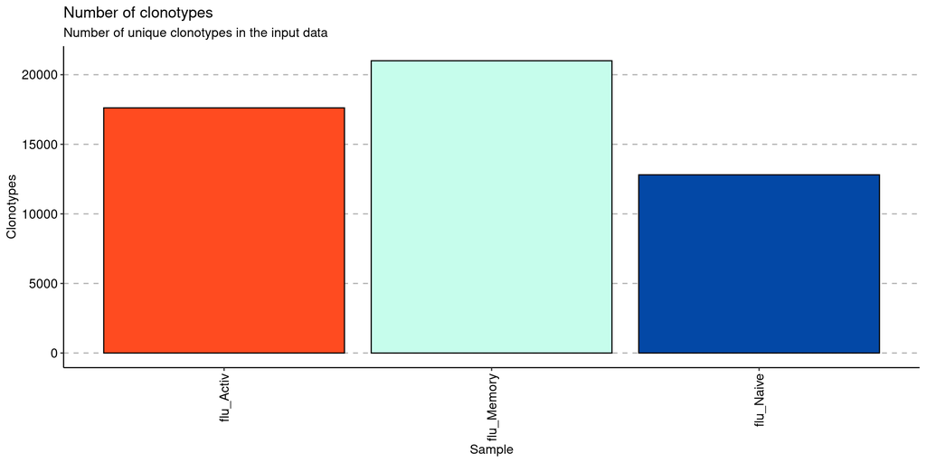

```r
vis(repExplore(scdata_cl$data, .method = "volume"))
```

Compare J gene usage between three clusters:

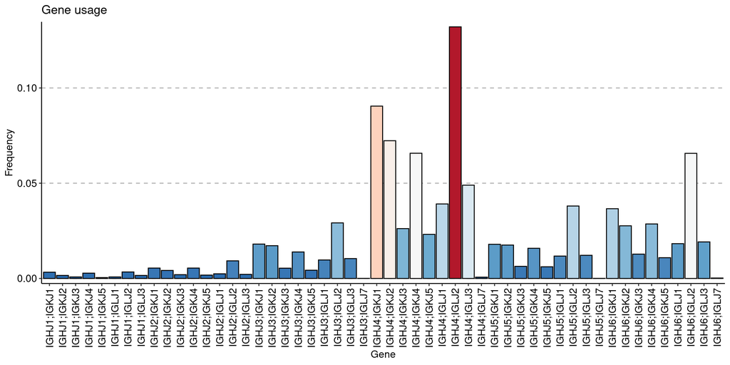

```r
sc_active <- geneUsage(repFilter(scdata_cl, .method = "by.meta", .query = list(Cluster = include('Activ')))$data, "hs.trbj", .norm = T)
p1 <- vis(sc_active)
p1
```

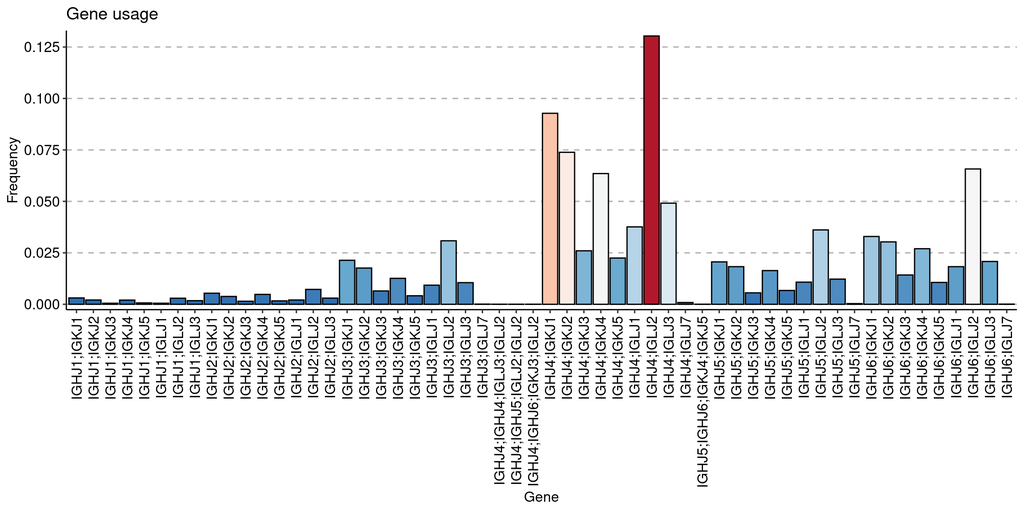

```r
sc_memory <- geneUsage(repFilter(scdata_cl, .method = "by.meta", .query = list(Cluster = include('Memory')))$data, "hs.trbj", .norm = T)
p2 <- vis(sc_memory)
p2
```

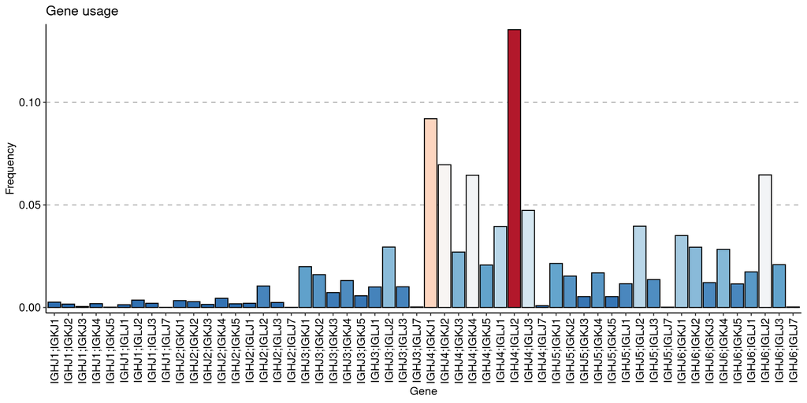

```r
sc_naive <- geneUsage(repFilter(scdata_cl, .method = "by.meta", .query = list(Cluster = include('Naive')))$data, "hs.trbj", .norm = T)
p3 <- vis(sc_naive)
p3
```

Compare gene usage of IGHJ4 between three clusters:

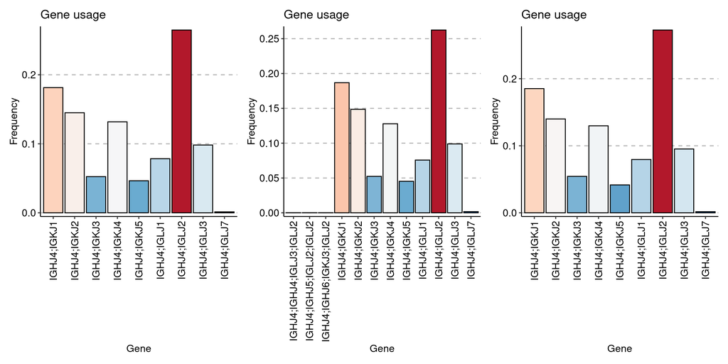

```r
scdata_active <- repFilter(scdata_cl, .method = "by.meta", .query = list(Cluster = include('Activ')))
scdata_active <- repFilter(scdata_active, .method = "by.cl", .query = list(J.name = include('IGHJ4')), .match = 'substring')
sc_active <- geneUsage(scdata_active$data, "hs.trbj", .norm = T)
p1 <- vis(sc_active)
scdata_memory <- repFilter(scdata_cl, .method = "by.meta", .query = list(Cluster = include('Memory')))
scdata_memory <- repFilter(scdata_memory, .method = "by.cl", .query = list(J.name = include('IGHJ4')), .match = 'substring')
sc_memory <- geneUsage(scdata_memory$data, "hs.trbj", .norm = T)
p2 <- vis(sc_memory)
scdata_naive <- repFilter(scdata_cl, .method = "by.meta", .query = list(Cluster = include('Naive')))
scdata_naive <- repFilter(scdata_naive, .method = "by.cl", .query = list(J.name = include('IGHJ4')), .match = 'substring')
sc_naive <- geneUsage(scdata_naive$data, "hs.trbj", .norm = T)
p3 <- vis(sc_naive)
p1 + p2 + p3
```

Look at the coding clonotypes in each cluster. Note that there aren’t any noncoding clonotypes in the datasets:

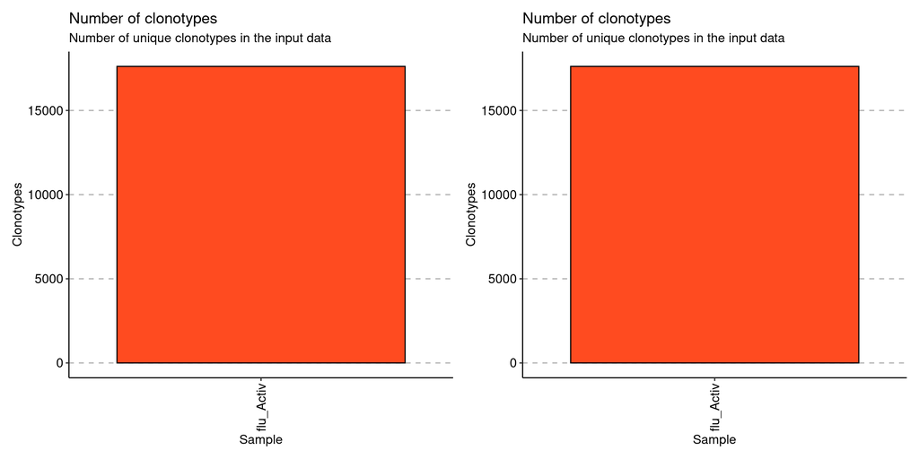

```r
scdata_active <- repFilter(scdata_cl, .method = "by.meta", .query = list(Cluster = include('Activ')))
scdata_active <- repFilter(scdata_active, .method = "by.clonotype", .query = list(CDR3.aa = exclude("partial", "out_of_frame")))
exp_vol <- repExplore(scdata_active$data, .method = "volume")
p1 <- vis(exp_vol)

exp_vol <- repExplore(repFilter(scdata_cl, .method = "by.meta", .query = list(Cluster = include('Activ')))$data, .method = "volume")
p2 <- vis(exp_vol)
p1+p2
```

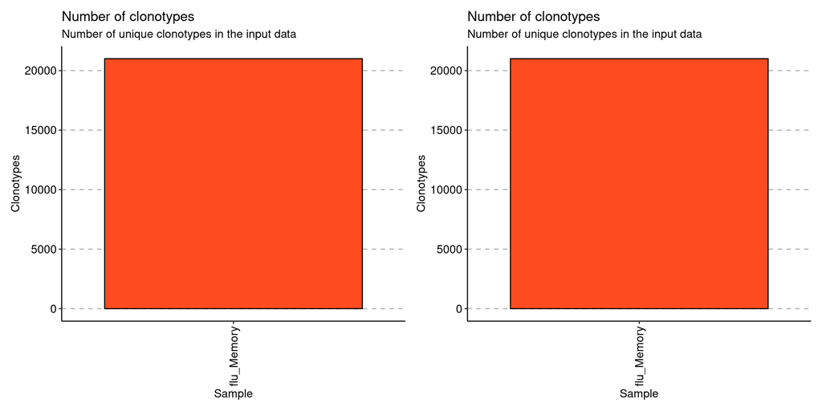

```r
scdata_memory <- repFilter(scdata_cl, .method = "by.meta", .query = list(Cluster = include('Memory')))
scdata_memory <- repFilter(scdata_memory, .method = "by.clonotype", .query = list(CDR3.aa = exclude("partial", "out_of_frame")))
exp_vol <- repExplore(scdata_memory$data, .method = "volume")
p1 <- vis(exp_vol)

exp_vol <- repExplore(repFilter(scdata_cl, .method = "by.meta", .query = list(Cluster = include('Memory')))$data, .method = "volume")
p2 <- vis(exp_vol)
p1+p2
```

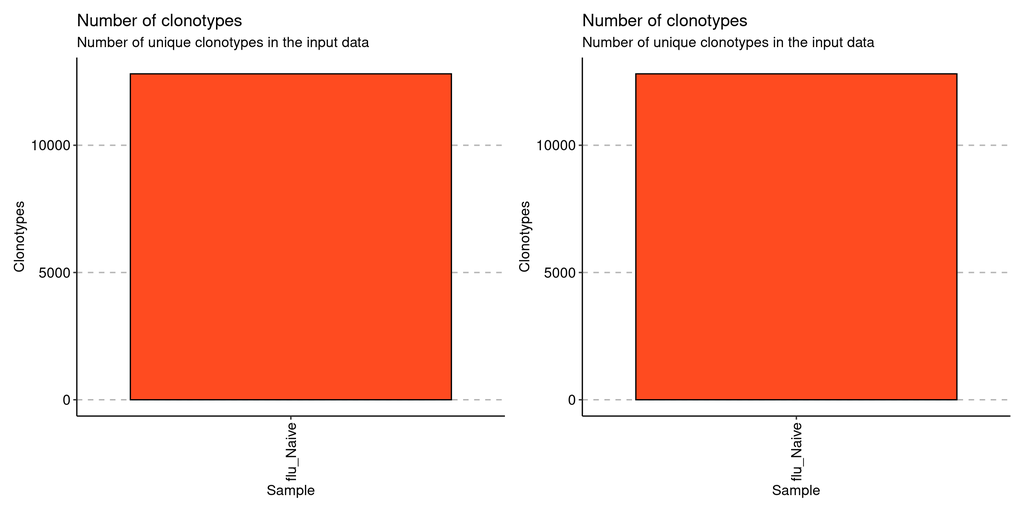

```r
scdata_naive <- repFilter(scdata_cl, .method = "by.meta", .query = list(Cluster = include('Naive')))
scdata_naive <- repFilter(scdata_naive, .method = "by.clonotype", .query = list(CDR3.aa = exclude("partial", "out_of_frame")))
exp_vol <- repExplore(scdata_naive$data, .method = "volume")
p1 <- vis(exp_vol)

exp_vol <- repExplore(repFilter(scdata_cl, .method = "by.meta", .query = list(Cluster = include('Naive')))$data, .method = "volume")
p2 <- vis(exp_vol)
p1+p2
```